# Lake Erie Water Levels - A Time Series Analysis (Part 4/4)

> - 👟 Ready To Run!
> - 🚀 Data Exploration and Cleaning
> - 🤖 Machine Learning
> - ⏱️ Time Series Analysis

So far, in this study, we have looked at **Univariate** time series modeling techniques where a single variable `Water Level` varied over time. Next, we will look at **Multivariate** [1] time series analysis where each variable depends not only on its past values but also has some dependency on past values of other variables. We will predict how `Water Level` in Lake Erie varies over time along with other variables such as `Precipitation` and `Air Temperature` over the lake.

We will use continue to use [Mean Water Level (m)](https://www.lre.usace.army.mil/Missions/Great-Lakes-Information/Great-Lakes-Information-2/Water-Level-Data/) data for Lake Erie. We will also bring in [Precipitation (mm)](https://www.glerl.noaa.gov/ftp/publications/tech_reports/glerl-083/UpdatedFiles/) data for Erie basin (land+lake) and [Mean Air Temperature (${^\circ}C$)](https://www.glerl.noaa.gov/data/dashboard/data/hydroIO/sourceSpreadsheets/) over Lake Erie.

# Table of Contents

In this notebook, we will:

- Read Water level, Precipitation and Air Temperature data for Lake Erie and index it as a time series
- Discuss Stationarity of data
- Difference the data to make it stationary
- Identify optimal VARMA(p,q) order using grid search
- Split the data
- Built and fit optimal VARMA model
  - Obtain Predictions
- Evaluate Model performance
  - Plot predictions and calculate loss

# Part 4: VARMA Models

```python
# General Imports
import pandas as pd
import itertools
import time

# Imports for Visualization
import matplotlib.pyplot as plt
%matplotlib inline
import seaborn as sns

# Time Series Imports
from statsmodels.tsa.stattools import adfuller
from statsmodels.tsa.statespace.tools import diff
from statsmodels.graphics.tsaplots import plot_acf, plot_pacf
from statsmodels.tsa.statespace.varmax import VARMAX, VARMAXResults
from statsmodels.tools.eval_measures import rmse


# Ignore harmless warnings
import warnings
warnings.filterwarnings("ignore")
```

## Read and Preprocess Data

We will use [Mean Water Level](https://www.lre.usace.army.mil/Missions/Great-Lakes-Information/Great-Lakes-Information-2/Water-Level-Data/) data for Lake Erie, [Precipitation](https://www.glerl.noaa.gov/ftp/publications/tech_reports/glerl-083/UpdatedFiles/) data for Erie basin (land+lake) and [Mean Air Temperature](https://www.glerl.noaa.gov/data/dashboard/data/hydroIO/sourceSpreadsheets/) data over Lake Erie. We’ll need to do some quick processing to read the data and convert it to have a time series index.

### Mean Air Temperature Data

The air temperature data is available for the period Jan'1948 - Dec'2019 and is measured in ${^\circ}C$. The data is in a table format with `Year` as rows and each `Month` as a column. It needs to be converted to the correct format so that each `Year-Month` combination is a row. We will read the data and process it for use.

```python
# Read data
air_temp = pd.read_csv('Erie_AirTemp.csv')
air_temp.head()
```

|  | Year | Jan | Feb | Mar | Apr | May | Jun | Jul | Aug | Sep | Oct | Nov | Dec |
| --- | --- | --- | --- | --- | --- | --- | --- | --- | --- | --- | --- | --- | --- |
| 0 | 1948 | -7.08 | -3.82 | 1.70 | 9.68 | 12.30 | 18.82 | 22.42 | 21.23 | 18.65 | 9.92 | 7.73 | 0.58 |
| 1 | 1949 | 0.38 | 0.03 | 1.83 | 7.12 | 14.80 | 21.99 | 23.92 | 22.19 | 15.73 | 14.15 | 4.50 | 1.10 |
| 2 | 1950 | 1.36 | -2.74 | -1.11 | 4.81 | 13.62 | 18.84 | 20.56 | 20.65 | 16.66 | 13.15 | 3.13 | -3.35 |
| 3 | 1951 | -2.20 | -2.41 | 2.10 | 7.15 | 14.24 | 19.04 | 21.59 | 20.26 | 16.91 | 13.00 | 1.79 | -1.09 |
| 4 | 1952 | -1.21 | -1.45 | 1.35 | 8.67 | 12.65 | 20.96 | 23.76 | 21.13 | 17.76 | 9.04 | 6.39 | 1.19 |

```python
# Convert rows to columns
air_temp = air_temp.melt(id_vars='Year', var_name='Month', value_name='Temp(C)')
```

```python
# Create date column from Year and Month
air_temp['date'] = pd.to_datetime(air_temp.Year.astype(str) + '-' + air_temp.Month.astype(str))
```

```python
# Drop Year and Month cols
air_temp.drop(columns = ['Year', 'Month'], inplace=True)
```

```python
# Sort dataframe by date
air_temp.sort_values(by=['date'], inplace=True)
air_temp.head()
```

|  | Temp(C) | date |
| --- | --- | --- |
| 0 | -7.08 | 1948-01-01 |
| 72 | -3.82 | 1948-02-01 |
| 144 | 1.70 | 1948-03-01 |
| 216 | 9.68 | 1948-04-01 |
| 288 | 12.30 | 1948-05-01 |

```python
# Print Min and Max values
print(min(air_temp['date']))
print(max(air_temp['date']))
```

```
1948-01-01 00:00:00
2019-12-01 00:00:00
```

```python
# Set date as index
air_temp.set_index('date', inplace=True)
air_temp.head()
```

| date | Temp(C) |
| --- | --- |
| 1948-01-01 | -7.08 |
| 1948-02-01 | -3.82 |
| 1948-03-01 | 1.70 |
| 1948-04-01 | 9.68 |
| 1948-05-01 | 12.30 |

### Precipitation Data

The precipiation data is available for the period Jan'1940 - Dec'2019 and is measured in "mm". This data is also in a table format with `Year` as rows and each `Month` as a column and . The data needs to be converted to the correct format so that each `Year-Month` combination is a row. We will read the data and process it for use.

```python
# Read data
prec_data = pd.read_csv('erie_precipitation.csv')
prec_data.head()
```

|  | YYYY | Jan | Feb | Mar | Apr | May | Jun | Jul | Aug | Sep | Oct | Nov | Dec |
| --- | --- | --- | --- | --- | --- | --- | --- | --- | --- | --- | --- | --- | --- |
| 0 | 1940 | 43.33 | 56.34 | 60.84 | 85.20 | 105.98 | 115.51 | 51.04 | 117.42 | 56.04 | 58.01 | 83.60 | 86.72 |
| 1 | 1941 | 47.12 | 24.49 | 33.44 | 42.03 | 65.40 | 88.56 | 73.08 | 69.69 | 34.59 | 105.22 | 55.24 | 44.83 |
| 2 | 1942 | 44.83 | 67.85 | 85.49 | 60.02 | 112.47 | 84.91 | 113.05 | 78.22 | 92.14 | 76.74 | 92.73 | 74.12 |
| 3 | 1943 | 50.39 | 41.97 | 67.62 | 84.96 | 171.98 | 83.87 | 139.35 | 67.10 | 68.60 | 61.48 | 45.46 | 19.64 |
| 4 | 1944 | 26.54 | 53.74 | 82.09 | 104.72 | 93.48 | 90.67 | 43.93 | 77.09 | 70.31 | 32.26 | 54.35 | 67.89 |

```python
# Convert rows to columns
prec_data = prec_data.melt(id_vars='YYYY', var_name='Month', value_name='Prec(mm)')
```

```python
# Create date column from Year and Month
prec_data['date'] = pd.to_datetime(prec_data.YYYY.astype(str) + '-' + prec_data.Month.astype(str))
```

```python
# Drop Year and Month cols
prec_data.drop(columns = ['YYYY', 'Month'], inplace=True)
```

```python
# Sort dataframe by date
prec_data.sort_values(by=['date'], inplace=True)
prec_data.head()
```

|  | Prec(mm) | date |
| --- | --- | --- |
| 0 | 43.33 | 1940-01-01 |
| 80 | 56.34 | 1940-02-01 |
| 160 | 60.84 | 1940-03-01 |
| 240 | 85.20 | 1940-04-01 |
| 320 | 105.98 | 1940-05-01 |

```python
# Print Min and Max values
print(prec_data.shape)
print(min(prec_data['date']))
print(max(prec_data['date']))
```

```
(960, 2)
1940-01-01 00:00:00
2019-12-01 00:00:00
```

Since air temperature data is available starting from Jan'1948, we will subset precipitation data for the same time period.

```python
# Subset data
prec_data = prec_data[prec_data['date']>='1948-01-01']
prec_data.head()
```

|  | Prec(mm) | date |
| --- | --- | --- |
| 8 | 45.46 | 1948-01-01 |
| 88 | 63.61 | 1948-02-01 |
| 168 | 110.12 | 1948-03-01 |
| 248 | 81.60 | 1948-04-01 |
| 328 | 102.88 | 1948-05-01 |

```python
# Set date as index
prec_data.set_index('date', inplace=True)
prec_data.head()
```

| date | Prec(mm) |
| --- | --- |
| 1948-01-01 | 45.46 |
| 1948-02-01 | 63.61 |
| 1948-03-01 | 110.12 |
| 1948-04-01 | 81.60 |
| 1948-05-01 | 102.88 |

### Mean Water Level Data

The mean water level data is available for the period Jan'1918 - Dec'2019 and is measured in "m". We will continue to use Lake Erie water level data we have used so far in this study.

```python
erie_data = pd.read_csv('erie_data')
erie_data.head()
```

|  | date | Erie | SES12 | DES12 | TES12 |
| --- | --- | --- | --- | --- | --- |
| 0 | 1918-01-01 | 173.90 | 173.900000 | 173.881745 | 173.859612 |
| 1 | 1918-02-01 | 173.82 | 173.887692 | 173.749419 | 173.880169 |
| 2 | 1918-03-01 | 174.01 | 173.906509 | 174.160248 | 174.171219 |
| 3 | 1918-04-01 | 174.02 | 173.923969 | 174.051395 | 174.139210 |
| 4 | 1918-05-01 | 173.98 | 173.932589 | 173.950891 | 174.031776 |

```python
# Convert date to datetime column
erie_data['date'] = pd.to_datetime(erie_data['date'])
erie_data.dtypes
```

```
date     datetime64[ns]
Erie            float64
SES12           float64
DES12           float64
TES12           float64
dtype: object
```

```python
# Drop cols
erie_data.drop(columns=['SES12','DES12','TES12'], inplace=True)
```

```python
# Rename Erie col to Water level
erie_data = erie_data.rename(columns={'Erie':'Water_level(m)'})
```

```python
# Print Min and Max values
print(erie_data.shape)
print(min(erie_data['date']))
print(max(erie_data['date']))
```

```
(1224, 2)
1918-01-01 00:00:00
2019-12-01 00:00:00
```

Since air temperature data is available starting from Jan'1948, we will subset water level data for the same time period.

```python
# Subset Data
erie_data = erie_data[erie_data['date']>='1948-01-01']
erie_data.head()
```

|  | date | Water_level(m) |
| --- | --- | --- |
| 360 | 1948-01-01 | 174.08 |
| 361 | 1948-02-01 | 173.99 |
| 362 | 1948-03-01 | 174.14 |
| 363 | 1948-04-01 | 174.38 |
| 364 | 1948-05-01 | 174.50 |

```python
# Set date as index
erie_data.set_index('date', inplace=True)
```

### Merge Data

We will merge water level, precipitation and air temperature data into a single dataframe.

```python
erie_data = erie_data.join(air_temp)
erie_data.head()
```

| date | Water_level(m) | Temp(C) |
| --- | --- | --- |
| 1948-01-01 | 174.08 | -7.08 |
| 1948-02-01 | 173.99 | -3.82 |
| 1948-03-01 | 174.14 | 1.70 |
| 1948-04-01 | 174.38 | 9.68 |
| 1948-05-01 | 174.50 | 12.30 |

```python
erie_data = erie_data.join(prec_data)
erie_data.head()
```

| date | Water_level(m) | Temp(C) | Prec(mm) |
| --- | --- | --- | --- |
| 1948-01-01 | 174.08 | -7.08 | 45.46 |
| 1948-02-01 | 173.99 | -3.82 | 63.61 |
| 1948-03-01 | 174.14 | 1.70 | 110.12 |
| 1948-04-01 | 174.38 | 9.68 | 81.60 |
| 1948-05-01 | 174.50 | 12.30 | 102.88 |

### Setting a DatetimeIndex Frequency

Note that our DatetimeIndex does not have a frequency. In order to build models, statsmodels needs to know the frequency of the data (whether it's daily, monthly etc.). Since observations occur at the start of each month, we'll use MS. A full list of time series offset aliases can be found [here](http://pandas.pydata.org/pandas-docs/stable/user_guide/timeseries.html#offset-aliases).

```python
# Set Frequency
erie_data.index.freq = 'MS'
erie_data.index
```

```
DatetimeIndex(['1948-01-01', '1948-02-01', '1948-03-01', '1948-04-01',
               '1948-05-01', '1948-06-01', '1948-07-01', '1948-08-01',
               '1948-09-01', '1948-10-01',
               ...
               '2019-03-01', '2019-04-01', '2019-05-01', '2019-06-01',
               '2019-07-01', '2019-08-01', '2019-09-01', '2019-10-01',
               '2019-11-01', '2019-12-01'],
              dtype='datetime64[ns]', name='date', length=864, freq='MS')
```

## VARMA Models

*Represented as:* VARMA (p,q)

VARMA (*Vector Autoregressive Moving Average*) models [1] [[2]](https://online.stat.psu.edu/stat510/lesson/11/11.2) [3] evaluate multiple variables where each variable depends not only on its past values but also has some dependency on past values of other variables.

A K-dimensional VARMA model of order $(p,q)$ considers each variable $y_K$ in the data.

For example, the system of equations for a 2-dimensional VARMA(1,1) model is:

$y_{1,t} = c_1 + \phi_{11,1}y_{1,t-1} + \phi_{12,1}y_{2,t-1} + \theta_{11,1}\varepsilon_{1,t-1} + \theta_{12,1}\varepsilon_{2,t-1} + \varepsilon_{1,t}$  
$y_{2,t} = c_2 + \phi_{21,1}y_{1,t-1} + \phi_{22,1}y_{2,t-1} + \theta_{21,1}\varepsilon_{1,t-1} + \theta_{22,1}\varepsilon_{2,t-1} + \varepsilon_{2,t}$

where:  
coefficient $\phi_{ii,l}$ captures the influence of the $l$th lag of variable $y_i$ on itself,  
coefficient $\phi_{ij,l}$ captures the influence of the $l$th lag of variable $y_j$ on $y_i$,  
coefficient $\theta_{ii,l}$ captures the influence of the $l$th lag of error $\varepsilon_i$ on itself,  
coefficient $\theta_{ij,l}$ captures the influence of the $l$th lag of error $\varepsilon_j$ on $\varepsilon_i$,  
and $\varepsilon_{1,t}$ and $\varepsilon_{2,t}$ are residual white noise.

We will follow this 8 step process to build, validate VARMA model and forecast for future periods:

**Step 1** — Visualize the data.  
**Step 2** — Check stationarity: If a time series has a trend or seasonality component, it must be made stationary before we can model the data.  
**Step 3** — Difference: If the time series is not stationary, it needs to be stationarized through differencing. Take the first difference, then check for stationarity.  
**Step 4** — Select the optimal *p* and *q* terms for model order.  
**Step 5** — Split the data into train and test sets.  
**Step 6** — Build the model: Build the model and obtain predictions on test data.  
**Step 7** — Invert transform the data.  
**Step 8** — Validate model: Compare the predicted values to the actuals in the test sample.

### Step 1 - Visualize the Data

[figure not shown]

```python
fig, axes = plt.subplots(3,1, figsize=(15,12))

erie_data['Water_level(m)'].plot(title='Mean Water Levels (in metres)', ax=axes[0])
erie_data['Temp(C)'].plot(title='Avg. Monthly Temperature (in Celsius)', ax=axes[1])
erie_data['Prec(mm)'].plot(title='Mean Precipitation (in mm)', ax=axes[2])
axes[0].set(xlabel='')
axes[1].set(xlabel='')
axes[2].set(xlabel='')

fig.tight_layout(pad=1.0)
plt.show()
```

> The plot above shows Mean water level, Temperature and Precipitation variation for Lake Erie. The data for Water Level shows an increasing and then decreasing trend. The data for Average Monthly Temperature shows no trend but seasonality. The data for Mean Precipitation shows a slight trend with seasonality and cyclic variations. Let's test the data for *Stationarity*.

### Step 2 - Test for Stationarity

To effectively use time series models, we need to understand if our data is stationary. A **stationary series** [[2]](https://people.duke.edu/~rnau/411diff.htm) has constant mean and variance over time. A time series that shows seasonality is *not* stationary.

A test for stationarity usually involves a hypothesis test, where the null hypothesis $H_0$ is that the series is *nonstationary*. The alternate hypothesis $H_1$ supports stationarity. To determine whether a series is stationary we can use the [augmented Dickey-Fuller Test](https://en.wikipedia.org/wiki/Augmented_Dickey-Fuller_test).

We will define a function that creates more informative output from the `adfuller()` test. We will use **AIC** for the autolag because it penalizes higher order models over simpler models.

```python
# Define the adf-test function

def aug_dftest(series, title=''):

    print(f'Augmented Dickey Fuller Test for: {title}')
    result = adfuller(series.dropna(), autolag='AIC') # dropna() handles differenced data

    labels = ['ADF test statistic','p-value','# lags used','# observations']
    output = pd.Series(result[0:4], index=labels)
    for key, val in result[4].items():
        output[f'critical value ({key})'] = val

    print(output.to_string())

    if output[1] <= 0.05:
        print('Reject the Null hypothesis; Data is stationary')
    else:
        print('Fail to reject the Null hypothesis; Data is non-stationary')
```

```python
# Run Test on each variable
for col in erie_data:
    aug_dftest(erie_data[col], title=col)
    print()
```

```
Augmented Dickey Fuller Test for: Water_level(m)
ADF test statistic       -2.557847
p-value                   0.102026
# lags used              18.000000
# observations          845.000000
critical value (1%)      -3.438112
critical value (5%)      -2.864966
critical value (10%)     -2.568595
Fail to reject the Null hypothesis; Data is non-stationary

Augmented Dickey Fuller Test for: Temp(C)
ADF test statistic     -5.856578e+00
p-value                 3.488693e-07
# lags used             2.100000e+01
# observations          8.420000e+02
critical value (1%)    -3.438140e+00
critical value (5%)    -2.864979e+00
critical value (10%)   -2.568601e+00
Reject the Null hypothesis; Data is stationary

Augmented Dickey Fuller Test for: Prec(mm)
ADF test statistic      -24.788931
p-value                   0.000000
# lags used               0.000000
# observations          863.000000
critical value (1%)      -3.437950
critical value (5%)      -2.864895
critical value (10%)     -2.568556
Reject the Null hypothesis; Data is stationary
```

Both temperature and precipitation variables are stationary, however water level variable is not. Let's difference the data to make it stationary.

### Step 3 - Differencing

**Differencing** [[3]](https://otexts.com/fpp2/) is a method of transforming a non-stationary time series into a stationary one. Often the data is not stationary but differences in data might be stationary. If there is an obvious upward or downward linear trend, a first difference may be needed. A quadratic trend might need a 2nd order difference. Often (not always) a first difference (non-seasonal) will “detrend” the data.

The first differencing value ${y}^\prime_{t}$ is the difference between the observation at current time period ${y}_{t}$ and the previous time period ${y}_{t-1}$. If these values fail to revolve around a constant mean and variance then we find the second differencing using the values of the first differencing.

First Order Differencing \begin{array}{l} y_{t}^{\prime} &=y_{t}-y_{t-1} \\ \end{array}

Second Order Differencing \begin{array}{l} y_{t}^{\prime \prime} &=y_{t}^{\prime}-y_{t-1}^{\prime} \\ &=\left(y_{t}-y_{t-1}\right)-\left(y_{t-1}-y_{t-2}\right) \\ &=y_{t}-2 y_{t-1}+y_{t-2} \end{array}

We'll take a first order difference of the entire DataFrame and re-run the augmented Dickey-Fuller tests.

```python
# Difference the data
erie_transformed = erie_data.diff()
```

```python
# Drop NA values
erie_transformed = erie_transformed.dropna()

# Run Test on each variable
for col in erie_data:
    aug_dftest(erie_data[col], title=col)
    print()
```

[output not shown]

### Step 4 - Optimal Order (p,q)

Our goal here is to find the optimal set of model orders (p,q) that yields the best performance for our model. We will run a grid search with different values of AR(p) and MA(q) terms.

We will:

1. Create a list of different model orders to iterate over.
2. Define a function that iterates through these orders to find the best VARMA model with the lowest AIC.

The function will evaluate all models created during the stepwise operation and list the best VARMA model along with its AIC score. The recommended order is the one with the lowest [Akaike Information Criterion](https://en.wikipedia.org/wiki/Akaike_information_criterion) or AIC score. The AIC value will allow us to compare how well a model fits the data and takes into account the complexity of a model, so models that have a better fit while using fewer features will receive a better (lower) AIC score than similar models that utilize more features.

```python
# Create a list of ARIMA model orders

p = q = range(0, 6)
pq = list(itertools.product(p, q))
print(pq)
```

```
[(0, 0), (0, 1), (0, 2), (0, 3), (0, 4), (0, 5), (1, 0), (1, 1), (1, 2), (1, 3), (1, 4), (1, 5), (2, 0), (2, 1), (2, 2), (2, 3), (2, 4), (2, 5), (3, 0), (3, 1), (3, 2), (3, 3), (3, 4), (3, 5), (4, 0), (4, 1), (4, 2), (4, 3), (4, 4), (4, 5), (5, 0), (5, 1), (5, 2), (5, 3), (5, 4), (5, 5)]
```

```python
from statsmodels.tsa.statespace.varmax import VARMAX, VARMAXResults

# Function to iterate over VARMA orders
def stepwise_arima(data):
    model_res = {}
    for param in pq:
        order_aic = []
        try:
            model = VARMAX(data, order=param, trend='c')
            model_fit = model.fit(maxiter=1000, disp=False)
            print(f'VARMA{param} - AIC: {model_fit.aic}')
            model_res[param] = model_fit.aic
        except:
            continue

#   Print model with lowest AIC
    low_key = min(model_res, key=model_res.get)
    print('\n')
    print('---------------------')
    print('MODEL WITH LOWEST AIC')
    print('---------------------')
    print(f'VARMA{low_key} - AIC: {model_res[low_key]}')
```

```python
# Run the model
stepwise_arima(erie_transformed)
```

```
VARMA(0, 1) - AIC: 10927.584294474686
VARMA(0, 2) - AIC: 10817.83428773417
VARMA(0, 3) - AIC: 10917.28923733559
VARMA(0, 4) - AIC: 10767.155111840013
VARMA(0, 5) - AIC: 10703.46873777406
VARMA(1, 0) - AIC: 10812.857441568016
VARMA(1, 1) - AIC: 10287.693015779276
VARMA(1, 2) - AIC: 10169.255144627745
VARMA(1, 3) - AIC: 10202.068136827704
VARMA(1, 4) - AIC: 10266.197629393806
VARMA(1, 5) - AIC: 10470.947493650605
VARMA(2, 0) - AIC: 10443.261607580705
VARMA(2, 1) - AIC: 10134.888598894773
VARMA(2, 2) - AIC: 9619.139106435141
VARMA(2, 3) - AIC: 9741.637181771464
VARMA(2, 4) - AIC: 9893.122845734946
VARMA(2, 5) - AIC: 9992.482279574771
VARMA(3, 0) - AIC: 10111.425344015883
VARMA(3, 1) - AIC: 9627.765420040938
VARMA(3, 2) - AIC: 9830.42421112183
VARMA(3, 3) - AIC: 9790.19141276467
VARMA(3, 4) - AIC: 9700.559540037539
VARMA(3, 5) - AIC: 9746.210152406711
VARMA(4, 0) - AIC: 9867.816602597377
VARMA(4, 1) - AIC: 9283.210210268599
VARMA(4, 2) - AIC: 9500.298701218588
VARMA(4, 3) - AIC: 9564.51839635842
VARMA(4, 4) - AIC: 9448.638452724328
VARMA(4, 5) - AIC: 9540.271510594474
VARMA(5, 0) - AIC: 9589.60613089416
VARMA(5, 1) - AIC: 9139.176849660413
VARMA(5, 2) - AIC: 9164.110682415027
VARMA(5, 3) - AIC: 9250.73093253131
VARMA(5, 4) - AIC: 9404.102129263021
VARMA(5, 5) - AIC: 9323.898187956052


---------------------
MODEL WITH LOWEST AIC
---------------------
VARMA(5, 1) - AIC: 9139.176849660413
```

> The function determined `VARMA(5,1)` as an optimal model. The recommended order is the one with the lowest Akaike information criterion or AIC score. Note that the recommended model may not be the one with the closest fit. The AIC score takes complexity into account, and tries to identify the best forecasting model.

Now that we have identified `VARMA(5,1)` as the optimal model, we will split the data and fit this model on training and test sets.

### Step 5 - Split the Data

It will be useful to define a number of observations variable for our test set. For this analysis, let's use data for last 60 months as test set.

```python
nobs=60
train, test = erie_transformed[0:-nobs], erie_transformed[-nobs:]
```

```python
print(train.shape)
print(test.shape)
```

```
(803, 3)
(60, 3)
```

### Step 6 - Build the Model

We will build and fit the VARMA(5, 1) model.

```python
model = VARMAX(train, order=(5, 1), trend='c')
results = model.fit(maxiter=1000, disp=False)
results.summary()
```

Statespace Model Results

| Dep. Variable: | ['Water_level(m)', 'Temp(C)', 'Prec(mm)'] | No. Observations: | 803 |
| --- | --- | --- | --- |
| Model: | VARMA(5,1) | Log Likelihood | -4195.825 |
|  | + intercept | AIC | 8517.649 |
| Date: | Sun, 13 Sep 2020 | BIC | 8813.015 |
| Time: | 19:25:04 | HQIC | 8631.095 |
| Sample: | 02-01-1948 |  |  |
|  | - 12-01-2014 |  |  |
| Covariance Type: | opg |  |  |

| Ljung-Box (Q): | 118.51, 81.96, 57.95 | Jarque-Bera (JB): | 82.69, 12.97, 20.76 |
| --- | --- | --- | --- |
| Prob(Q): | 0.00, 0.00, 0.03 | Prob(JB): | 0.00, 0.00, 0.00 |
| Heteroskedasticity (H): | 1.10, 0.98, 0.96 | Skew: | 0.47, -0.21, 0.31 |
| Prob(H) (two-sided): | 0.45, 0.84, 0.75 | Kurtosis: | 4.25, 3.47, 3.48 |

Results for equation Water_level(m)

|  | coef | std err | z | P>\|z\| | [0.025 | 0.975] |
| --- | --- | --- | --- | --- | --- | --- |
| intercept | -0.0002 | 0.002 | -0.096 | 0.923 | -0.004 | 0.004 |
| L1.Water_level(m) | 0.1063 | 0.238 | 0.446 | 0.656 | -0.361 | 0.574 |
| L1.Temp(C) | 0.0039 | 0.002 | 2.488 | 0.013 | 0.001 | 0.007 |
| L1.Prec(mm) | 0.0016 | 0.001 | 2.876 | 0.004 | 0.001 | 0.003 |
| L2.Water_level(m) | 0.0017 | 0.052 | 0.033 | 0.974 | -0.100 | 0.104 |
| L2.Temp(C) | -0.0036 | 0.002 | -2.107 | 0.035 | -0.007 | -0.000 |
| L2.Prec(mm) | 0.0013 | 0.001 | 2.558 | 0.011 | 0.000 | 0.002 |
| L3.Water_level(m) | 0.1099 | 0.052 | 2.098 | 0.036 | 0.007 | 0.212 |
| L3.Temp(C) | -0.0068 | 0.001 | -5.405 | 0.000 | -0.009 | -0.004 |
| L3.Prec(mm) | 0.0011 | 0.000 | 2.835 | 0.005 | 0.000 | 0.002 |
| L4.Water_level(m) | 0.1293 | 0.062 | 2.098 | 0.036 | 0.009 | 0.250 |
| L4.Temp(C) | -0.0046 | 0.002 | -2.292 | 0.022 | -0.009 | -0.001 |
| L4.Prec(mm) | 0.0007 | 0.000 | 2.203 | 0.028 | 7.27e-05 | 0.001 |
| L5.Water_level(m) | 0.0345 | 0.063 | 0.544 | 0.586 | -0.090 | 0.159 |
| L5.Temp(C) | -0.0042 | 0.002 | -2.676 | 0.007 | -0.007 | -0.001 |
| L5.Prec(mm) | 0.0003 | 0.000 | 1.783 | 0.075 | -2.79e-05 | 0.001 |
| L1.e(Water_level(m)) | -0.1588 | 0.237 | -0.671 | 0.502 | -0.623 | 0.305 |
| L1.e(Temp(C)) | -0.0004 | 0.002 | -0.210 | 0.834 | -0.004 | 0.003 |
| L1.e(Prec(mm)) | -0.0005 | 0.001 | -0.878 | 0.380 | -0.002 | 0.001 |

Results for equation Temp(C)

|  | coef | std err | z | P>\|z\| | [0.025 | 0.975] |
| --- | --- | --- | --- | --- | --- | --- |
| intercept | 0.0055 | 0.072 | 0.076 | 0.939 | -0.135 | 0.146 |
| L1.Water_level(m) | -4.5112 | 11.764 | -0.383 | 0.701 | -27.568 | 18.546 |
| L1.Temp(C) | 0.3984 | 0.080 | 4.971 | 0.000 | 0.241 | 0.556 |
| L1.Prec(mm) | 0.0598 | 0.031 | 1.911 | 0.056 | -0.002 | 0.121 |
| L2.Water_level(m) | 6.0320 | 3.036 | 1.987 | 0.047 | 0.082 | 11.982 |
| L2.Temp(C) | 0.0415 | 0.092 | 0.452 | 0.651 | -0.138 | 0.221 |
| L2.Prec(mm) | 0.0529 | 0.027 | 1.928 | 0.054 | -0.001 | 0.107 |
| L3.Water_level(m) | 2.1178 | 3.099 | 0.683 | 0.494 | -3.957 | 8.192 |
| L3.Temp(C) | -0.1544 | 0.068 | -2.269 | 0.023 | -0.288 | -0.021 |
| L3.Prec(mm) | 0.0451 | 0.022 | 2.023 | 0.043 | 0.001 | 0.089 |
| L4.Water_level(m) | 14.4403 | 3.205 | 4.505 | 0.000 | 8.158 | 20.722 |
| L4.Temp(C) | -0.2614 | 0.105 | -2.489 | 0.013 | -0.467 | -0.056 |
| L4.Prec(mm) | 0.0251 | 0.016 | 1.541 | 0.123 | -0.007 | 0.057 |
| L5.Water_level(m) | -2.5946 | 3.260 | -0.796 | 0.426 | -8.984 | 3.794 |
| L5.Temp(C) | -0.3925 | 0.083 | -4.725 | 0.000 | -0.555 | -0.230 |
| L5.Prec(mm) | 0.0029 | 0.009 | 0.307 | 0.759 | -0.016 | 0.021 |
| L1.e(Water_level(m)) | -0.5461 | 11.511 | -0.047 | 0.962 | -23.108 | 22.016 |
| L1.e(Temp(C)) | -0.9064 | 0.068 | -13.319 | 0.000 | -1.040 | -0.773 |
| L1.e(Prec(mm)) | -0.0641 | 0.031 | -2.059 | 0.040 | -0.125 | -0.003 |

Results for equation Prec(mm)

|  | coef | std err | z | P>\|z\| | [0.025 | 0.975] |
| --- | --- | --- | --- | --- | --- | --- |
| intercept | -0.0822 | 1.078 | -0.076 | 0.939 | -2.195 | 2.031 |
| L1.Water_level(m) | -60.9691 | 73.318 | -0.832 | 0.406 | -204.669 | 82.731 |
| L1.Temp(C) | 1.7739 | 0.639 | 2.777 | 0.005 | 0.522 | 3.026 |
| L1.Prec(mm) | -0.7268 | 0.195 | -3.728 | 0.000 | -1.109 | -0.345 |
| L2.Water_level(m) | -46.7644 | 23.215 | -2.014 | 0.044 | -92.265 | -1.264 |
| L2.Temp(C) | 1.3350 | 0.625 | 2.137 | 0.033 | 0.111 | 2.559 |
| L2.Prec(mm) | -0.5320 | 0.178 | -2.987 | 0.003 | -0.881 | -0.183 |
| L3.Water_level(m) | -52.6401 | 22.981 | -2.291 | 0.022 | -97.683 | -7.597 |
| L3.Temp(C) | 1.2115 | 0.492 | 2.463 | 0.014 | 0.248 | 2.175 |
| L3.Prec(mm) | -0.3644 | 0.144 | -2.523 | 0.012 | -0.647 | -0.081 |
| L4.Water_level(m) | -21.4982 | 24.555 | -0.876 | 0.381 | -69.626 | 26.629 |
| L4.Temp(C) | -0.1265 | 0.676 | -0.187 | 0.852 | -1.452 | 1.199 |
| L4.Prec(mm) | -0.2408 | 0.104 | -2.313 | 0.021 | -0.445 | -0.037 |
| L5.Water_level(m) | -43.3006 | 20.073 | -2.157 | 0.031 | -82.642 | -3.959 |
| L5.Temp(C) | -1.0387 | 0.509 | -2.040 | 0.041 | -2.037 | -0.041 |
| L5.Prec(mm) | -0.1004 | 0.062 | -1.625 | 0.104 | -0.222 | 0.021 |
| L1.e(Water_level(m)) | 6.8105 | 71.951 | 0.095 | 0.925 | -134.212 | 147.833 |
| L1.e(Temp(C)) | -0.1609 | 0.838 | -0.192 | 0.848 | -1.804 | 1.482 |
| L1.e(Prec(mm)) | -0.0484 | 0.189 | -0.257 | 0.797 | -0.418 | 0.321 |

Error covariance matrix

|  | coef | std err | z | P>\|z\| | [0.025 | 0.975] |
| --- | --- | --- | --- | --- | --- | --- |
| sqrt.var.Water_level(m) | 0.0566 | 0.001 | 43.699 | 0.000 | 0.054 | 0.059 |
| sqrt.cov.Water_level(m).Temp(C) | 0.2842 | 0.074 | 3.867 | 0.000 | 0.140 | 0.428 |
| sqrt.var.Temp(C) | 1.8833 | 0.049 | 38.741 | 0.000 | 1.788 | 1.979 |
| sqrt.cov.Water_level(m).Prec(mm) | 12.5972 | 0.988 | 12.754 | 0.000 | 10.661 | 14.533 |
| sqrt.cov.Temp(C).Prec(mm) | 1.4881 | 1.066 | 1.396 | 0.163 | -0.601 | 3.578 |
| sqrt.var.Prec(mm) | 24.8267 | 0.626 | 39.686 | 0.000 | 23.601 | 26.053 |

Warnings:  
[1] Covariance matrix calculated using the outer product of gradients (complex-step).

#### Model Diagnostics

We will run model diagnostics to investigate any unusual behavior.

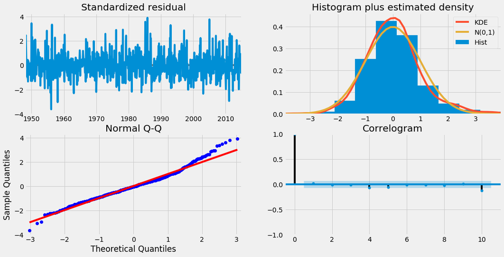

```python
with plt.style.context('fivethirtyeight'):
    results.plot_diagnostics(figsize=(16,8))
    plt.show()
```

> The properties of residuals should reflect the properties of underlying process. Model diagnostics suggests [5] that:
> 1. Residuals do not show a pattern
> 2. The ACF plot shows only 1st lag =1. All other lags are are small and within the confidence band.
> 3. Model residuals are near normally distributed.

*Top Right* : The density plot suggest normal distribution with mean zero.

*Bottom left* : All the dots should fall perfectly in line with some deviations towards the right implying skewed distribution.

*Bottom Right* : The Correlogram, aka, ACF plot shows the residual errors are not autocorrelated. Any autocorrelation would imply that there is some pattern in the residual errors which are not explained in the model.

#### Predict for next 60 months

We will use the VARMA(5,1) model to forecast for the next 60 months.

```python
erie_forecast = results.forecast(60)
erie_forecast.head()
```

|  | Water_level(m) | Temp(C) | Prec(mm) |
| --- | --- | --- | --- |
| 2015-01-01 | -0.009948 | -3.454743 | 20.633181 |
| 2015-02-01 | 0.043344 | 0.537420 | 0.224909 |
| 2015-03-01 | 0.061179 | 2.491800 | 6.027532 |
| 2015-04-01 | 0.089384 | 6.309388 | 4.976766 |
| 2015-05-01 | 0.069648 | 4.993909 | -2.845398 |

### Step 7 - Invert the Transformation

Remember that the forecasted values represent first-order differences. To compare them to the original data we have to roll back each difference. To roll back a first-order difference we take the most recent value on the training side of the original series, and add it to a cumulative sum of forecasted values.

```python
# Build the forecast values from the first difference set
erie_forecast['Water_Forecast'] = erie_data['Water_level(m)'].iloc[-nobs-1]
                                    + erie_forecast['Water_level(m)'].cumsum()
```

```python
# Now build the forecast values from the first difference set
erie_forecast['Temp_Forecast'] = erie_data['Temp(C)'].iloc[-nobs-1] + erie_forecast['Temp(C)'].cumsum()
```

```python
# Now build the forecast values from the first difference set
erie_forecast['Prec_Forecast'] = erie_data['Prec(mm)'].iloc[-nobs-1] + erie_forecast['Prec(mm)'].cumsum()
```

```python
erie_forecast.head()
```

|  | Water_level(m) | Temp(C) | Prec(mm) | Water_Forecast | Temp_Forecast | Prec_Forecast |
| --- | --- | --- | --- | --- | --- | --- |
| 2015-01-01 | -0.009948 | -3.454743 | 20.633181 | 174.160052 | -1.384743 | 50.173181 |
| 2015-02-01 | 0.043344 | 0.537420 | 0.224909 | 174.203396 | -0.847323 | 50.398091 |
| 2015-03-01 | 0.061179 | 2.491800 | 6.027532 | 174.264574 | 1.644476 | 56.425622 |
| 2015-04-01 | 0.089384 | 6.309388 | 4.976766 | 174.353959 | 7.953864 | 61.402388 |
| 2015-05-01 | 0.069648 | 4.993909 | -2.845398 | 174.423607 | 12.947773 | 58.556990 |

#### Combine Forecasts

We will combine forecasts with original data in a dataframe.

```python
test_df = pd.concat([erie_data.iloc[-60:],erie_forecast[['Water_Forecast','Temp_Forecast','Prec_Forecast']]],axis=1)
```

```python
test_df.head()
```

| date | Water_level(m) | Temp(C) | Prec(mm) | Water_Forecast | Temp_Forecast | Prec_Forecast |
| --- | --- | --- | --- | --- | --- | --- |
| 2015-01-01 | 174.16 | -3.9 | 45.28 | 174.160052 | -1.384743 | 50.173181 |
| 2015-02-01 | 174.03 | -3.4 | 50.56 | 174.203396 | -0.847323 | 50.398091 |
| 2015-03-01 | 173.99 | 1.6 | 25.33 | 174.264574 | 1.644476 | 56.425622 |
| 2015-04-01 | 174.22 | 7.7 | 86.07 | 174.353959 | 7.953864 | 61.402388 |
| 2015-05-01 | 174.31 | 13.7 | 126.41 | 174.423607 | 12.947773 | 58.556990 |

### Step 8 - Validate Model Results

#### Plot the results

We will plot `VARMA(5,1)` predictions along with Test set.

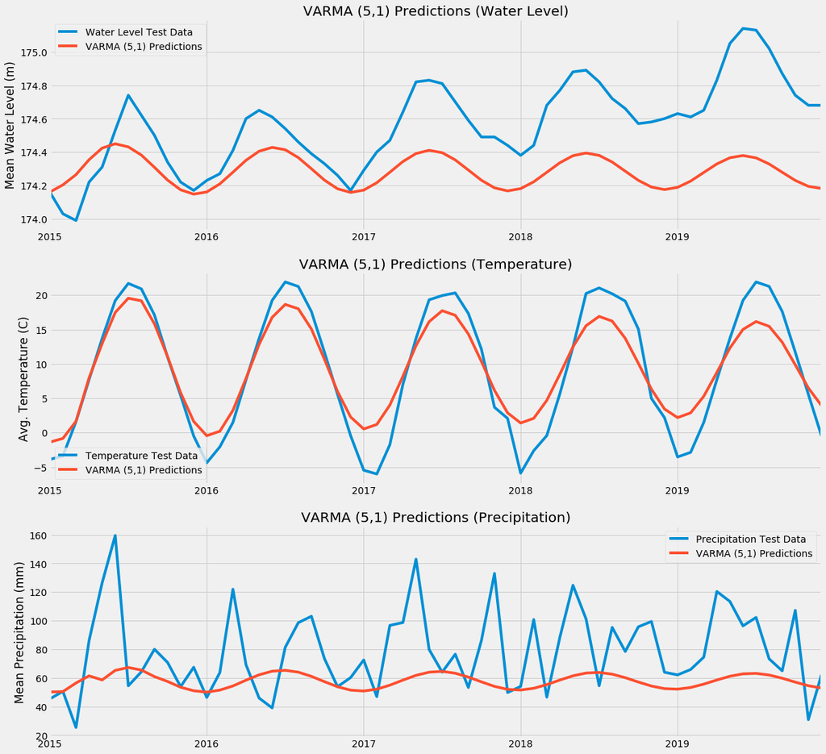

```python
with plt.style.context('fivethirtyeight'):
    fig, axes = plt.subplots(3,1, figsize=(18,18))

    # Water Level
    title = 'VARMA (5,1) Predictions (Water Level)'
    label = 'VARMA (5,1) Predictions'
    test_df['Water_level(m)'].plot(label='Water Level Test Data', legend=True, ax=axes[0], title=title)
    test_df['Water_Forecast'].plot(label=label, legend=True, ax=axes[0])
    axes[0].set(xlabel="",ylabel="Mean Water Level (m)")

    # Temperature
    title = 'VARMA (5,1) Predictions (Temperature)'
    label = 'VARMA (5,1) Predictions'
    test_df['Temp(C)'].plot(label='Temperature Test Data', legend=True, ax=axes[1], title=title)
    test_df['Temp_Forecast'].plot(label=label, legend=True, ax=axes[1])
    axes[1].set(xlabel="",ylabel="Avg. Temperature (C)")

    # Precipitation
    title = 'VARMA (5,1) Predictions (Precipitation)'
    label = 'VARMA (5,1) Predictions'
    test_df['Prec(mm)'].plot(label='Precipitation Test Data', legend=True, ax=axes[2], title=title)
    test_df['Prec_Forecast'].plot(label=label, legend=True, ax=axes[2])
    axes[2].set(xlabel="",ylabel="Mean Precipitation (mm)")
```

#### Calculate Loss

We will calculate RMSE for each variable and compare to actual data.

```python
RMSE1 = rmse(test_df['Water_level(m)'], test_df['Water_Forecast'])
actual1 = max(test_df['Water_level(m)']) - min(test_df['Water_level(m)'])
print(f'Water Level RMSE: {RMSE1:.3f}')
print(f'Water Level Test Data Variation: {actual1:.2f}')
```

[output not shown]

```python
RMSE2 = rmse(test_df['Temp(C)'], test_df['Temp_Forecast'])
actual2 = max(test_df['Temp(C)']) - min(test_df['Temp(C)'])
print(f'Temperature RMSE: {RMSE2:.3f}')
print(f'Temperature Test Data Variation: {actual2:.2f}')
```

```
Temperature RMSE: 3.413
Temperature Test Data Variation: 27.93
```

```python
RMSE3 = rmse(test_df['Prec(mm)'], test_df['Prec_Forecast'])
actual3 = max(test_df['Prec(mm)']) - min(test_df['Prec(mm)'])
print(f'Precipitation RMSE: {RMSE3:.3f}')
print(f'Precipitation Test Data Variation: {actual3:.2f}')
```

```
Precipitation RMSE: 34.251
Precipitation Test Data Variation: 134.18
```

## Summary

To summarize, in this notebook we utilized a Multivariate Time Series modeling technique to:

1. Read Water level, Precipitation and Air Temperature data for Lake Erie and indexed it as a time series.
2. Checked stationarity of data and differenced the data to make it stationary.
3. Identified optimal VARMA(p,q) order using grid search.
4. Split the data, built and fit optimal VARMA model on the data.
5. Inverted the data.
6. Generated predictions and validated model performance.

Here is a summary of the models along with the RMSE that were created throughout the study.

| Model | RMSE |
| --- | --- |
| Double Exponential Smoothing | 2.232 |
| Triple Exponential Smoothing | 0.258 |
| ARIMA(2,1,2) | 0.294 |
| SARIMA(1,0,1)(2,1,0,12) | 0.321 |
| SARIMA(2,1,1)(0,1,2,12) | 0.299 |
| VARMA(5,1) for Water Level | 0.354 |
| VARMA(5,1) for Temperature | 3.413 |
| VARMA(5,1) for Precipitation | 34.251 |

## Conclusion

Time series are one of the most common data types encountered in daily life where data is collected at constant time intervals. Weather, stock prices, electricity usage, daily burger sales or even blood pressure variations are some of the examples of data that can be collected at regular intervals.

In this study, we explored one such example of forecasting water levels in Lake Erie. Various reports [[4]](https://www.theguardian.com/environment/2019/sep/03/great-lakes-region-flooding-climate-crisis) [[5]](https://www.eurekalert.org/pub_releases/2020-07/uot-srm070720.php) have shown that in recent years high water levels wreaked havoc on the communities bordering the Great Lakes leading to widespread damage in coastal cities.

The results from this study can be utilized by various state govt. executives, residents and small business owners to minimize the impacts of rising water levels on their daily lives, their livelihood and to better prepare for the future months.

## References

[1] Serban, N. (2018). Unit 3: Multivariate Time Series Modeling [Lecture Recording]. Georgia Institute of Technology. https://omscs.gatech.edu/isye-6402-time-series-analysis  
[2] https://online.stat.psu.edu/stat510/lesson/11/11.2  
[3] Lütkepohl H. (2005) Estimation of VARMA Models. In: New Introduction to Multiple Time Series Analysis. Springer, Berlin, Heidelberg.  
[4] https://www.theguardian.com/environment/2019/sep/03/great-lakes-region-flooding-climate-crisis  
[5] https://www.eurekalert.org/pub_releases/2020-07/uot-srm070720.php